# PM566 Midterm project

Yina Liu

10/7/2020

## Introduction

The entire dataset reflects incidents of crime in the City of Los Angeles dating back to 2020 (https://data.lacity.org/A-Safe-City/Crime-Data-from-2020-to-Present/2nrs-mtv8 ). After reviewing all the data, we found that so far, one of the most frequency crimes in L.A. is burglary.  
The primary interest of the project is:  
- The association of burglary and victims’ gender, age and descent.  
- Look at patterns in the time series and places of burglary happened in Los Angeles in 2020.

## Methods

This original dataset is obtained online from ‘Los Angeles Open Data’. It is provided by The Los Angeles Police Department. We collected the data on crimes and victims of burglary from January 1st, 2020 to October 5th, 2020. After importing, the data was carefully checked for variable names and types. Full descent names, provided in the data dictionary, were used instead of the victims’ descent codes. Descendants who have experienced only a few burglaries were merged together. For example, ‘Japanese’ and ‘Korean’ were both classified as ‘Asian’. We also created a variable called ‘month_occurance’, which refers to the month in which each burglary occurred. Finally, missing values and implausible values for key variables, such as ‘0’ in the age of the victims and ‘(0°,0°)’ in the latitude and longitude, were removed during data cleaning and wrangling.

In terms of data exploration, I used barcharts to show the number of burglary victims of different genders and descents, and boxplots to show the age of the victims. We also generated a barchart and a summary table to showing the number of burglaries in each Los Angeles area, as well as a leaflet map with detailed locations. Furthurmore, we created several line graphs to show the trend of number of burglaries by month.

## Preliminary Results

For patterns of burglaries by areas, we found that Wilshire, West LA and Pacific are the top three places with the most burglaries (671, 544 and 446 respectively), which together accounted for over a quarter of the total number of burglaries in Los Angeles. In the first half of the year, there were on average of 700 burglaries per month. This number reached the peak at 840 in May as the number of burglaries in Wilshire increased by three times compared with usual during that month. In the rest three months, the number of burlgaries in L.A. sharply decreased and dropped to 550 by August and September. In addition, there is no significant relationship between sex or descent of victims and month.

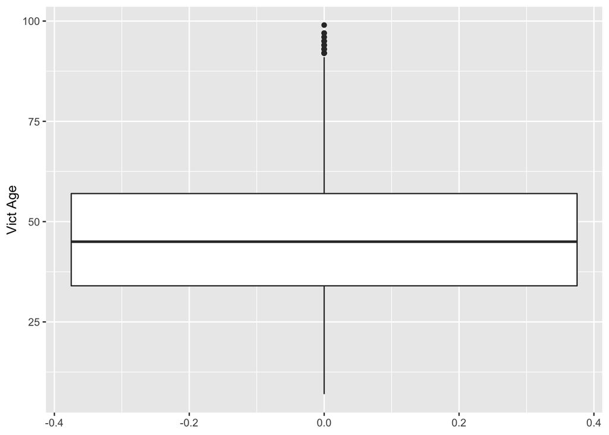

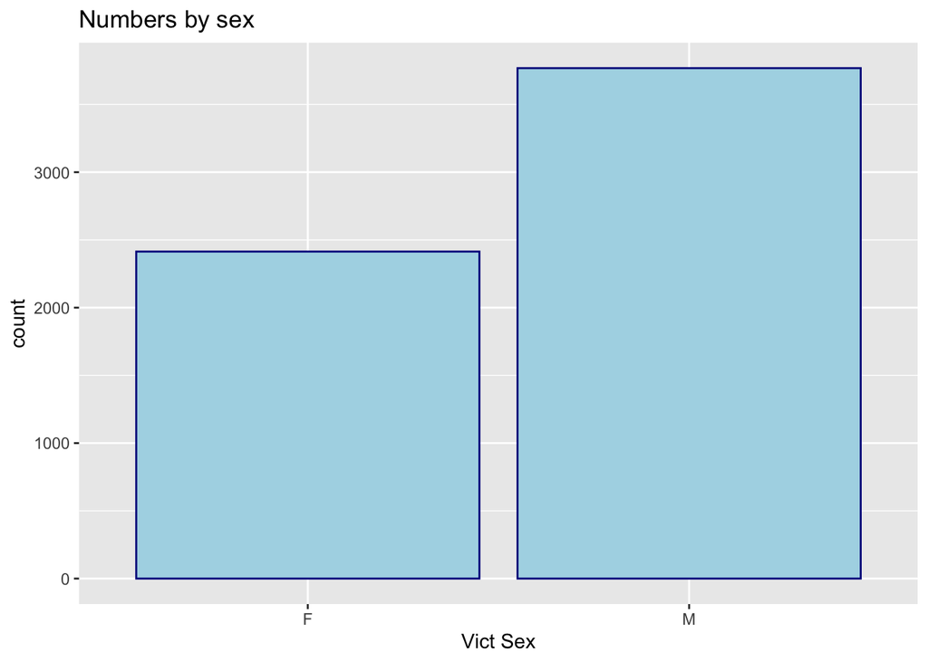

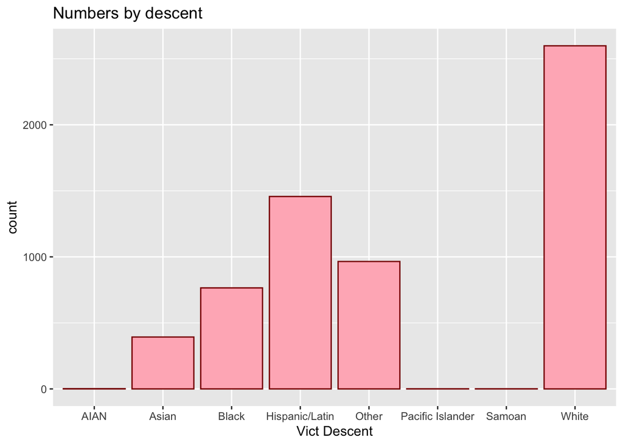

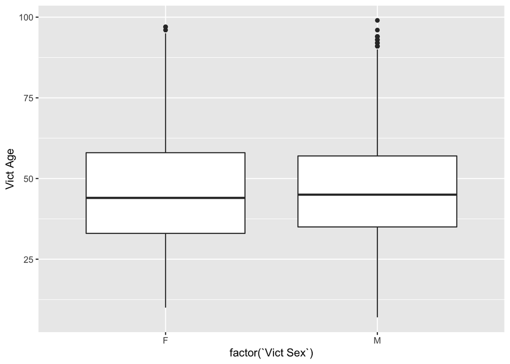

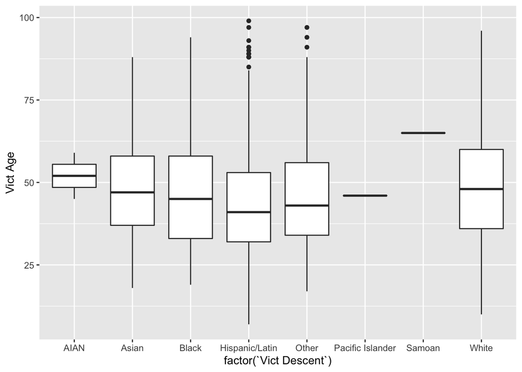

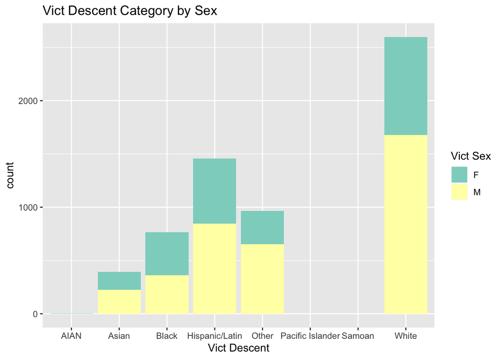

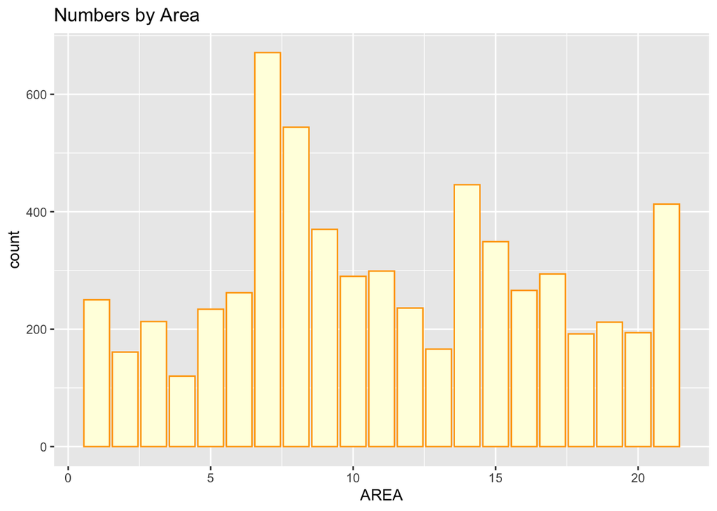

[interactive chart not shown]

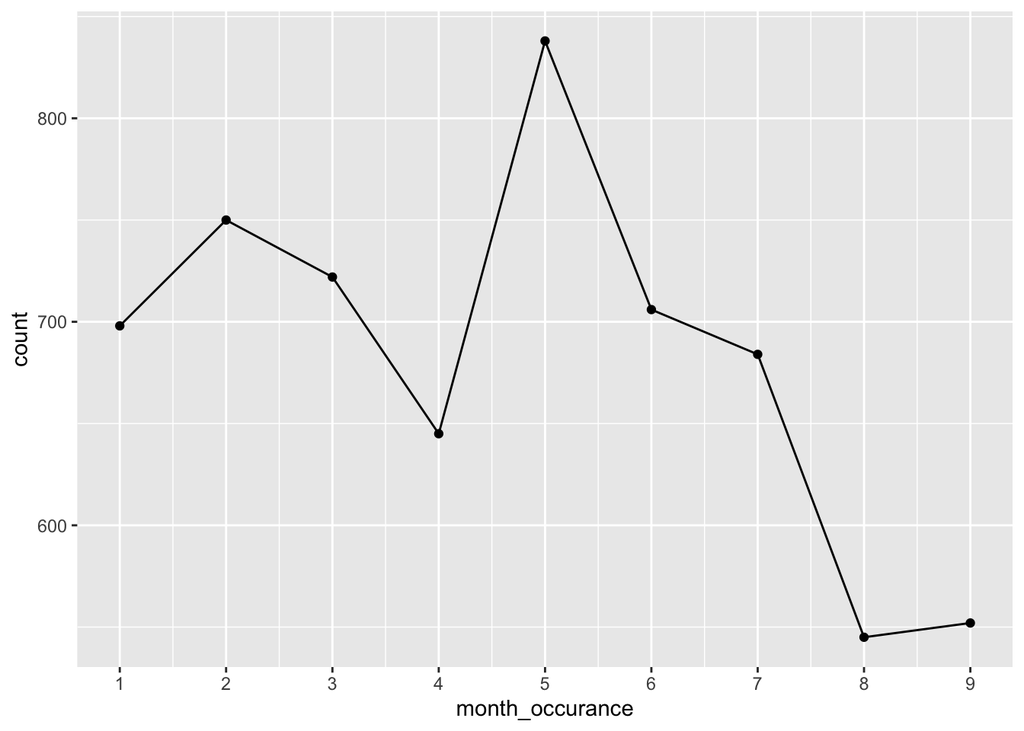

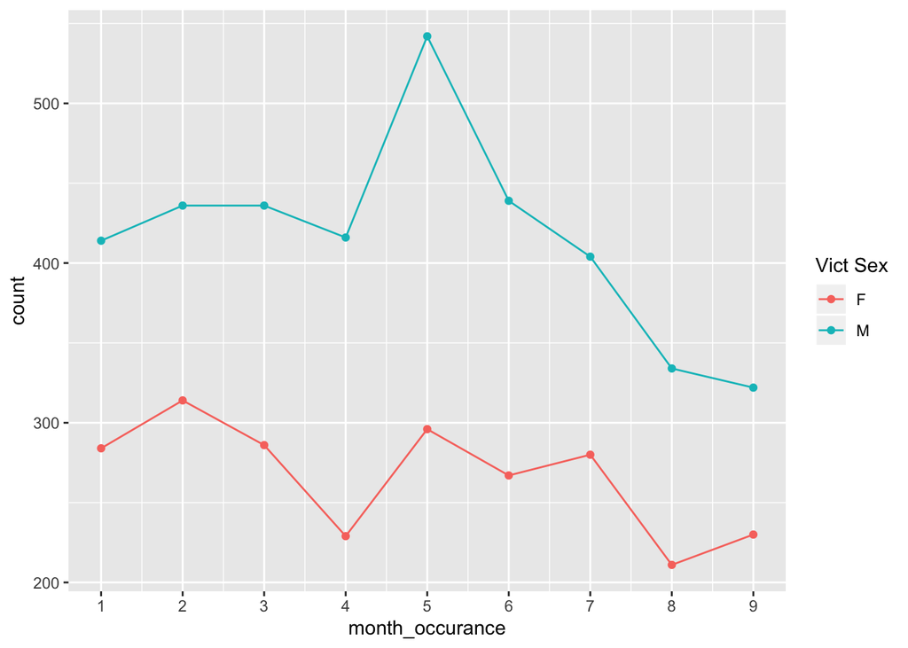

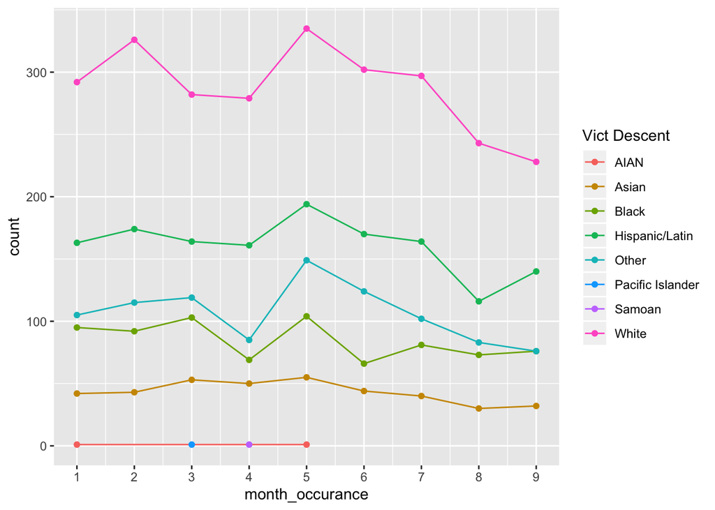

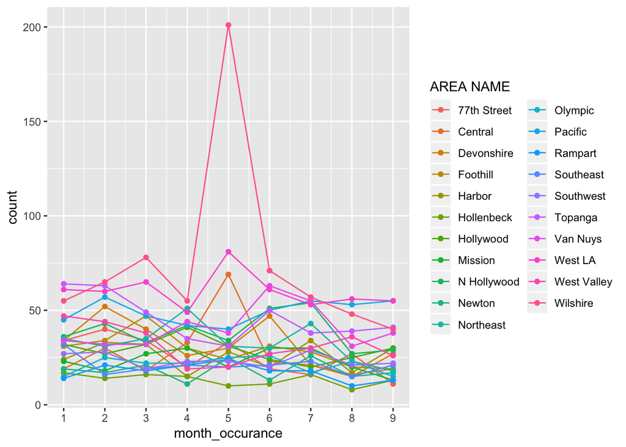

|  | AIAN (N = 2) | Asian (N = 393) | Black (N = 765) | Hispanic/Latin (N = 1457) | Other (N = 965) | Pacific Islander (N = 1) | Samoan (N = 1) | White (N = 2598) |
| --- | --- | --- | --- | --- | --- | --- | --- | --- |
| **Victim Age** |  |  |  |  |  |  |  |  |
| min | 45 | 18 | 19 | 7 | 17 | 46 | 65 | 10 |
| max | 59 | 88 | 94 | 99 | 97 | 46 | 65 | 96 |
| mean (sd) | 52.00 ± 9.90 | 47.88 ± 15.08 | 46.31 ± 15.79 | 43.27 ± 14.78 | 45.19 ± 14.93 | 46.00 ± NA | 65.00 ± NA | 48.91 ± 16.18 |
| **Victim Gender** |  |  |  |  |  |  |  |  |
| Male | 1 (50) | 226 (58) | 362 (47) | 846 (58) | 654 (68) | 1 (100) | 1 (100) | 1,677 (65) |
| Female | 1 (50) | 167 (42) | 403 (53) | 611 (42) | 311 (32) | 0 (0) | 0 (0) | 921 (35) |

|  | 1 | 2 | 3 | 4 | 5 | 6 | 7 | 8 | 9 | 10 | total |
| --- | --- | --- | --- | --- | --- | --- | --- | --- | --- | --- | --- |
| 1: Central | 19 | 30 | 18 | 33 | 69 | 23 | 21 | 16 | 19 | 2 | 250 |
| 10: West Valley | 47 | 44 | 38 | 19 | 20 | 27 | 30 | 36 | 26 | 3 | 290 |
| 11: Northeast | 35 | 31 | 35 | 51 | 31 | 30 | 43 | 23 | 18 | 2 | 299 |
| 12: 77th Street | 34 | 40 | 34 | 20 | 33 | 19 | 16 | 27 | 11 | 2 | 236 |
| 13: Newton | 19 | 17 | 21 | 11 | 25 | 13 | 26 | 15 | 17 | 2 | 166 |
| 14: Pacific | 45 | 57 | 47 | 42 | 40 | 50 | 55 | 53 | 55 | 2 | 446 |
| 15: N Hollywood | 36 | 43 | 33 | 42 | 34 | 51 | 54 | 27 | 29 | 0 | 349 |
| 16: Foothill | 31 | 34 | 47 | 30 | 24 | 31 | 28 | 20 | 19 | 2 | 266 |
| 17: Devonshire | 34 | 52 | 40 | 26 | 30 | 47 | 21 | 15 | 27 | 2 | 294 |
| 18: Southeast | 32 | 16 | 19 | 21 | 20 | 21 | 23 | 15 | 21 | 4 | 192 |
| 19: Mission | 23 | 18 | 27 | 30 | 20 | 30 | 30 | 20 | 13 | 1 | 212 |
| 2: Rampart | 14 | 21 | 18 | 21 | 24 | 18 | 18 | 10 | 13 | 4 | 161 |
| 20: Olympic | 15 | 25 | 22 | 22 | 25 | 26 | 17 | 23 | 15 | 4 | 194 |
| 21: Topanga | 64 | 63 | 49 | 35 | 31 | 50 | 38 | 39 | 41 | 3 | 413 |
| 3: Southwest | 27 | 28 | 19 | 23 | 23 | 20 | 29 | 21 | 22 | 1 | 213 |
| 4: Hollenbeck | 17 | 14 | 16 | 15 | 10 | 11 | 16 | 8 | 13 | 0 | 120 |
| 5: Harbor | 24 | 33 | 32 | 15 | 28 | 20 | 34 | 17 | 30 | 1 | 234 |
| 6: Hollywood | 32 | 27 | 32 | 41 | 31 | 24 | 20 | 25 | 30 | 0 | 262 |
| 7: Wilshire | 55 | 65 | 78 | 55 | 201 | 71 | 57 | 48 | 40 | 1 | 671 |
| 8: West LA | 61 | 60 | 65 | 49 | 81 | 61 | 53 | 56 | 55 | 3 | 544 |
| 9: Van Nuys | 34 | 32 | 32 | 44 | 38 | 63 | 55 | 31 | 38 | 3 | 370 |